# Lab: Machine Learning + Trees

36-600

To answer the questions below, it will help you to refer to the class notes and to Sections 8.1 and 8.3.1-8.3.2 of ISLR 1ed. *Note, however, that we use the rpart package to create trees, which ISLR does not use.* So ISLR is best used for looking up background details.

# Regression Trees

## Data, Part I

We’ll begin by importing the heart-disease dataset and log-transforming the response variable, `Cost`:

```r
df      <- read.csv("http://www.stat.cmu.edu/~pfreeman/heart_disease.csv",stringsAsFactors=TRUE)
df      <- df[,-10]
w       <- which(df$Cost > 0)
df      <- df[w,]
df$Cost <- log(df$Cost)
summary(df)
```

```
##       Cost             Age           Gender    Interventions
##  Min.   : 0.470   Min.   :24.00   Female:608   Min.   : 0.000
##  1st Qu.: 5.090   1st Qu.:55.00   Male  :177   1st Qu.: 1.000
##  Median : 6.235   Median :60.00                Median : 3.000
##  Mean   : 6.314   Mean   :58.73                Mean   : 4.722
##  3rd Qu.: 7.582   3rd Qu.:64.00                3rd Qu.: 6.000
##  Max.   :10.872   Max.   :70.00                Max.   :47.000
##      Drugs           ERVisit       Complications     Comorbidities
##  Min.   :0.0000   Min.   : 0.000   Min.   :0.00000   Min.   : 0.000
##  1st Qu.:0.0000   1st Qu.: 2.000   1st Qu.:0.00000   1st Qu.: 0.000
##  Median :0.0000   Median : 3.000   Median :0.00000   Median : 1.000
##  Mean   :0.3389   Mean   : 3.424   Mean   :0.05478   Mean   : 3.781
##  3rd Qu.:0.0000   3rd Qu.: 5.000   3rd Qu.:0.00000   3rd Qu.: 5.000
##  Max.   :2.0000   Max.   :20.000   Max.   :1.00000   Max.   :60.000
##     Duration
##  Min.   :  0.0
##  1st Qu.: 42.0
##  Median :167.0
##  Mean   :164.7
##  3rd Qu.:281.0
##  Max.   :372.0
```

## Question 1

Split the data into training and test sets. Call these `df.train` and `df.test`. Reuse the random number seed that you used when splitting the data prior to learning the multiple linear regression model in a previous lab.

```r
set.seed(100)
s<-sample(nrow(df), round(nrow(df)*0.7))
df.train<-df[s,]
df.test<-df[-s,]
lm.out<-lm(Cost~., df.train)
Cost.pred<-predict(lm.out, df.test)
mean((df.test$Cost-Cost.pred)^2)/nrow(df.test)
```

```
## [1] 0.007953492
```

## Question 2

Learn a regression tree model and report the test-set MSE. How does this MSE compare with what you observed for the linear model? Is it lower? If so, then the (inherently more flexible) nonlinear regression tree model is adapting better to the geometry of the data than the (inherently less flexible) linear model…with the tradeoff that inferential ability is reduced. (But not eliminated, as we’ll see.)

```r
suppressMessages(library(rpart))
rpart.out<- rpart(Cost~., df.train)
Cost2.pred<- predict(rpart.out, df.test)
mean((df.test$Cost-Cost2.pred)^2)/nrow(df.test)
```

```
## [1] 0.005854835
```

```
From calculating the mean squared error of both models it can be seen that the mean squared error of the tree model is smaller that the mean squared error of the linear regression model. This means that the tree model may be a better predictor that the regression model.
```

## Question 3

Visualize the tree. Install the package `rpart.plot` and run its namesake function while inputting the results of your tree fit. If you were of a mind to do inference, you’d look to see what variables lie at the top of the tree: these are presumably the ones with the most statistical information. (Note that because this is a regression tree, the `extra` argument to `rpart.plot()` won’t be useful here and you can leave it out of the function call.)

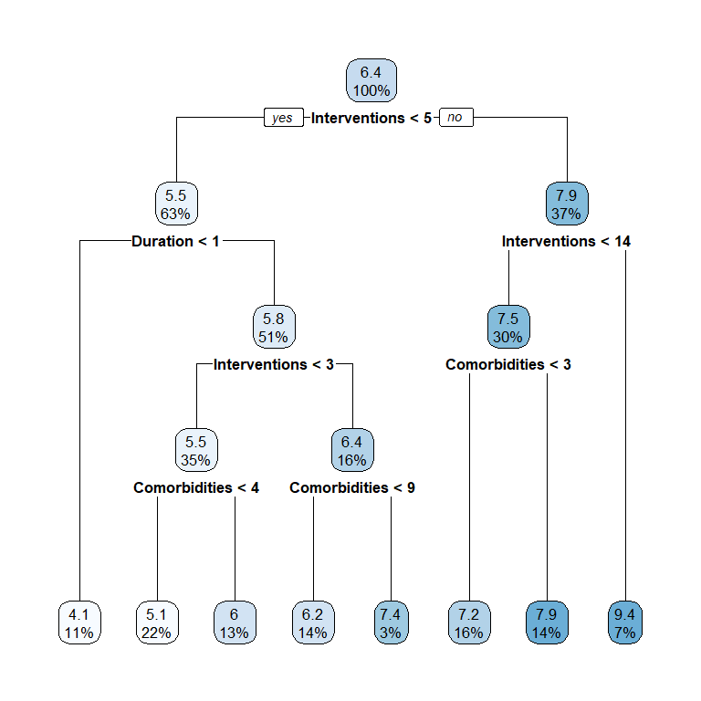

```r
suppressMessages(library(rpart.plot))
rpart.plot(rpart.out)
```

## Question 4

Create a diagnostic plot, specifically, the test-set predicted responses ($y$-axis) versus the test-set observed responses ($x$-axis). The predictions were generated in Question 2. For enhanced readability, be sure to set the $x$ limits and the $y$ limits to be the same, and add a line of slope one to the plot. Does the plot seem strange to you? If so, and you don’t know what is going on, call us over.

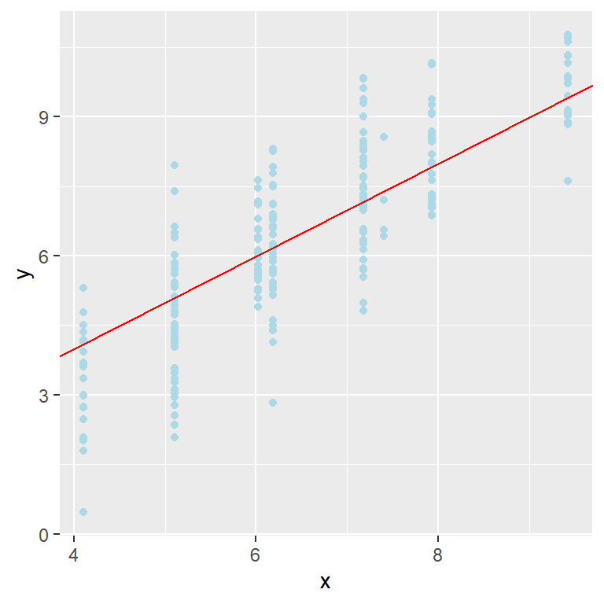

```r
library(ggplot2)
df.plot <- data.frame("x"=Cost2.pred, "y" = df.test$Cost)
ggplot(df.plot, mapping = aes(x = x, y = y), xlab = "Model Fitted values", ylab = "Model Residuals",lims = c(0, 12))+
  geom_point(color = "lightblue")+
  geom_abline(slope =  1, color = "red")
```

## Question 5

Run `plotcp()` with the output of your call to `rplot()` to see if the tree needs pruned. (Yes, it should be “needs to be pruned,” but you’re in Pittsburgh.) As a reminder, you are looking for the leftmost point that lies below the dotted line. If this is not the last point (the point farthest to the right), then `plotcp()` is trying to tell you to prune the tree. Note that depending on how you split the data, you may or may not see evidence that pruning is necessary.

Note that even if pruning is deemed necessary, you do not need to do that pruning here. You would, if necessary, go back to the code given in today’s notes to extract the pruned tree, which you can then use to, e.g., compute an MSE.

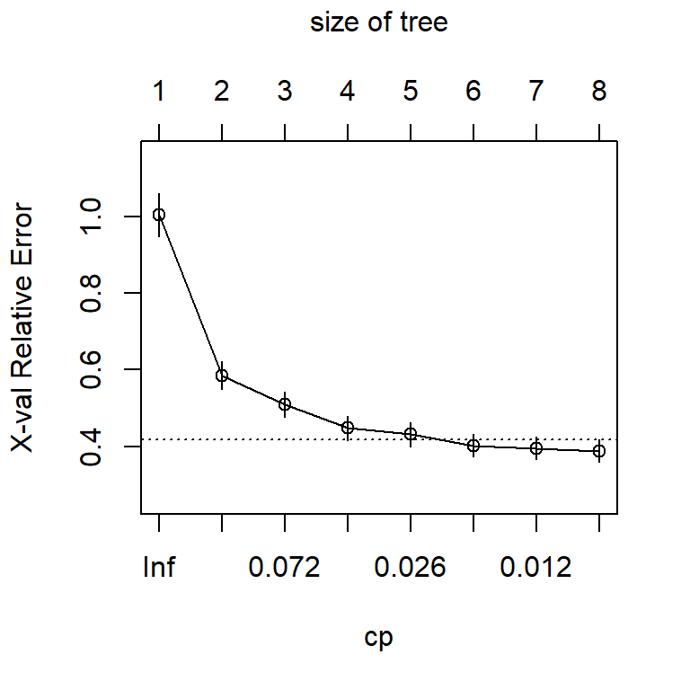

```r
plotcp(rpart.out)
```

# Classification Trees

Now we turn our attention to classification trees.

## Data, Part II

We will now load in the data on political movements that you looked at in the logistic regression lab:

```r
load(url("http://www.stat.cmu.edu/~pfreeman/movement.Rdata"))
f <- function(variable,level0="NO",level1="YES") {
  n               <- length(variable)
  new.variable    <- rep(level0,n)
  w               <- which(variable==1)
  new.variable[w] <- level1
  return(factor(new.variable))
}
predictors$nonviol      <- f(predictors$nonviol)
predictors$sanctions    <- f(predictors$sanctions)
predictors$aid          <- f(predictors$aid)
predictors$support      <- f(predictors$support)
predictors$viol.repress <- f(predictors$viol.repress)
predictors$defect       <- f(predictors$defect)
levels(response)        <- c("FAILURE","SUCCESS")
df           <- cbind(predictors,response)
names(df)[9] <- "label"
rm(id.half,id,predictors.half,predictors,response)
```

## Question 6

Split the data! If you can, match what you did in the logistic regression lab (as far as seed-setting is concerned).

```r
set.seed(100)
s<-sample(nrow(df), round(nrow(df)*0.8))
df.train<-df[s,]
df.test<-df[-s,]
```

## Question 7

Your next job is to learn a classification tree. Do that, and output a confusion matrix. (Note that the use of the `predict()` function might be, for you, a little different here: use `type="class"` as an argument, so that the output is not a probability but a classification. You can use the output directly when creating the confusion matrix.) What is the misclassification rate? (If you split your data in the same manner as you did for linear regression, is the MCR lower? Just make a mental note.)

```r
rpart2.out<-rpart(label~., data = df.train)
label.pred<- predict(rpart2.out, newdata = df.test, type = "class")
table(label.pred, df.test$label)
```

```
##
## label.pred FAILURE SUCCESS
##    FAILURE      21      13
##    SUCCESS       2       8
```

```r
mean(label.pred!=df.test$label)
```

```
## [1] 0.3409091
```

[output not shown]

## Question 8

Let’s compute the Area Under Curve (AUC) for the decision tree model. Dealing with prediction is a bit tricky as the argument change a bit from model to model, but what you’d want to do here is run

- resp.pred <- predict(rpart.out,newdata=df.test,type=“prob”)[,2]

and then mimic the material presented in the notes to generate an AUC.

```r
suppressMessages(library(pROC))
resp.prob <- predict(rpart2.out,newdata=df.test,type="prob")[,2]
roc.log <- roc(df.test$label,resp.prob)
roc.log$auc
```

```
## Area under the curve: 0.6667
```

## Question 9

Plot your classification tree (perhaps with the argument `extra=104` or `extra=106`) and determine if pruning is necessary using `plotcp()`. Make a mental note about the pruning…but see Question 10.

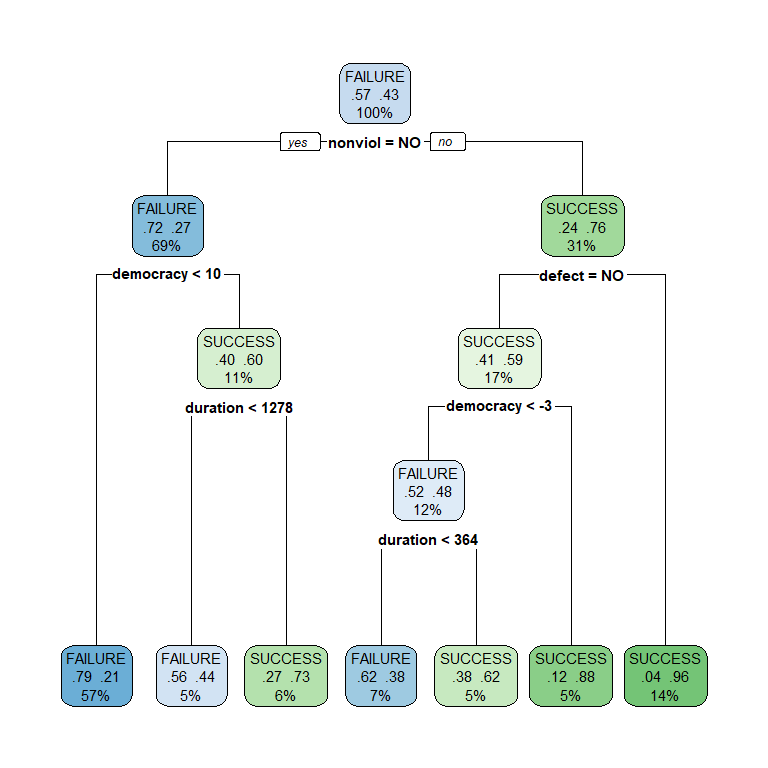

```r
rpart.plot(rpart2.out, extra = 104)
```

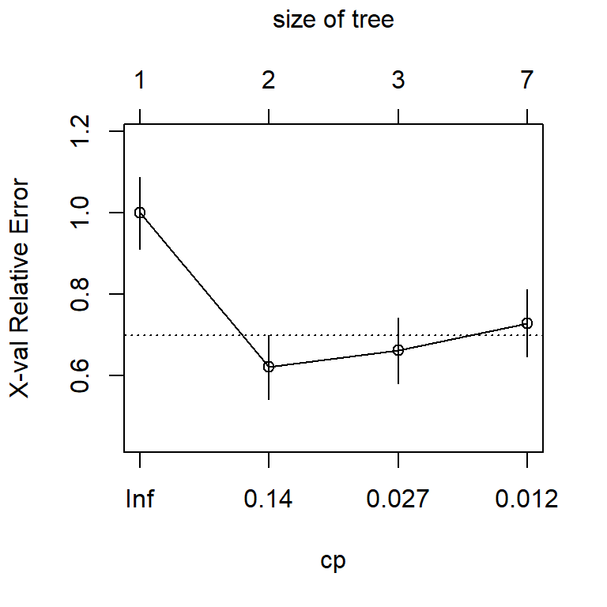

```r
plotcp(rpart2.out)
```

## Question 10

Here, I suspect you saw clear evidence that pruning would be useful. Go ahead, prune the tree and replot the pruned tree. Also, compute the misclassification rate: did pruning make things worse?

```r
rpart.pruned <- prune(rpart2.out,cp=0.14)
label.pred<- predict(rpart.pruned, newdata = df.test, type = "class")
table(label.pred, df.test$label)
```

```
##
## label.pred FAILURE SUCCESS
##    FAILURE      18      11
##    SUCCESS       5      10
```

```r
mean(label.pred!=df.test$label)
```

```
## [1] 0.3636364
```

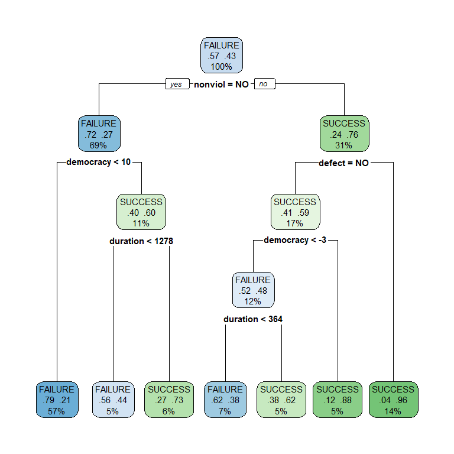

```r
rpart.plot(rpart2.out, extra = 104)
```

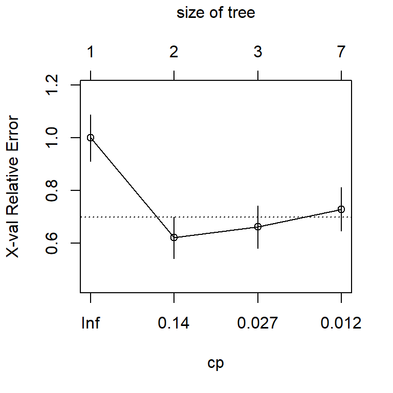

[output not shown]

```r
plotcp(rpart2.out)
```